# Sacramento Soil Moisture Accounting (SAC-SMA) Model

### *DO NOT USE - Currently under development*

## Model Description

The SAC-SMA is a continuous soil moisture accounting model with spatially lumped parameters that simulates runoff within a basin. The model divides the basin into lower and upper zones at different depths, and defines the distribution of moisture, i.e., tension water components (driven by evapotranspiration and diffusion) and free water components (driven by gravitational forces) in each of these two zones via a set of parameters. The model uses precipitation and temperature variables, along with parameters on soil moisture states and the basin’s relative permeability to estimate the amount of water that enters, is stored in, and leaves the basin. Thus, the model estimates several key hydrologic processes including evapotranspiration, percolation, interflow, and different forms of runoff from a basin.

Further information is available at: [NOAA - National Weather Service](http://www.nws.noaa.gov/oh/hrl/nwsrfs/users_manual/part2/_pdf/23sacsma.pdf)

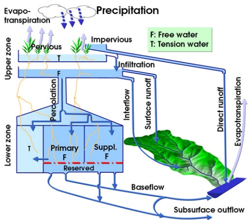

## R Version

The original model code is written in Fortran and is publicly accessible. The R version of the model is translated from the Matlab code developed by [Sungwook Wi](https://github.com/sungwookwi)